# Microbiome composition

Leo Lahti, Sudarshan Shetty et al.

Read example data from a [diet swap study](http://dx.doi.org/10.1038/ncomms7342):

```r
# Example data
library(microbiome)
library(dplyr)
data(dietswap)

# Make sure we use functions from correct package
transform <- microbiome::transform

# Merge rare taxa to speed up examples
pseq <- transform(dietswap, "compositional")
pseq <- aggregate_rare(pseq, level = "Genus", detection = 1/100, prevalence = 50/100)

# Pick sample subset
library(phyloseq)
pseq2 <- subset_samples(pseq, group == "DI" & nationality == "AFR" & timepoint.within.group == 1)

# Normal western adults
data(atlas1006)
pseq3 <- atlas1006 %>%
  subset_samples(DNA_extraction_method == "r") %>%
  aggregate_taxa(level = "Phylum") %>%
  microbiome::transform(transform = "compositional")
```

## Composition barplots

Same with compositional (relative) abundances; for each sample (left), or averafged by group (right).

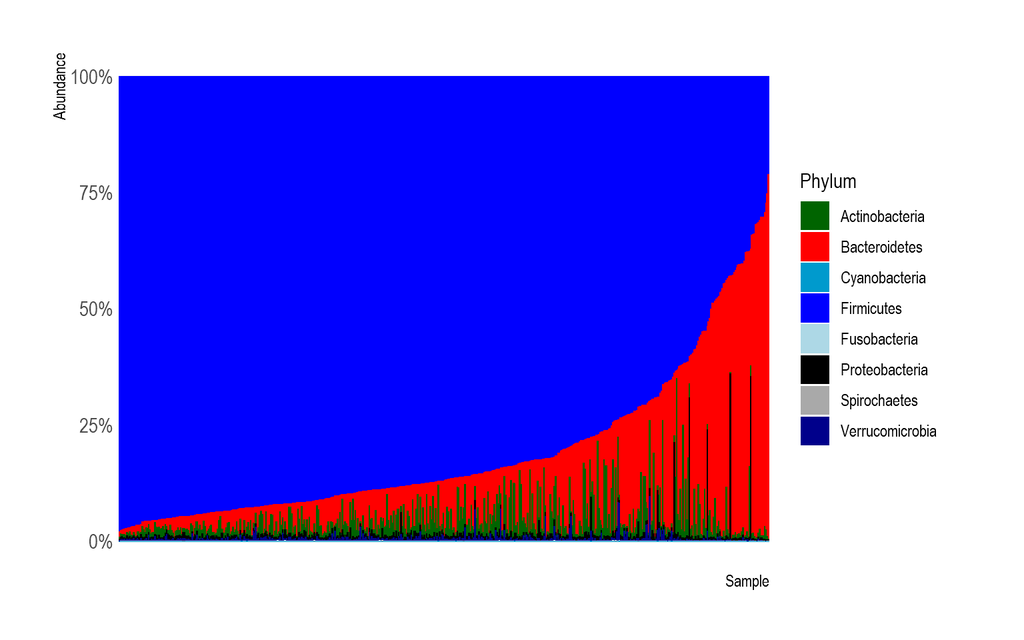

```r
# Try another theme
# from https://github.com/hrbrmstr/hrbrthemes
library(hrbrthemes)
library(gcookbook)
library(tidyverse)
#theme_set(theme_bw(21))
p <- pseq3 %>%
  plot_composition(sample.sort = "Firmicutes", otu.sort = "abundance") +
  # Set custom colors
  scale_fill_manual("Phylum",values = default_colors("Phylum")[taxa(pseq3)]) +
  scale_y_continuous(label = scales::percent) +
  theme_ipsum(grid="Y") +
  # Removes sample names and ticks
  theme(axis.text.x=element_blank(), axis.ticks.x=element_blank())
print(p)
```

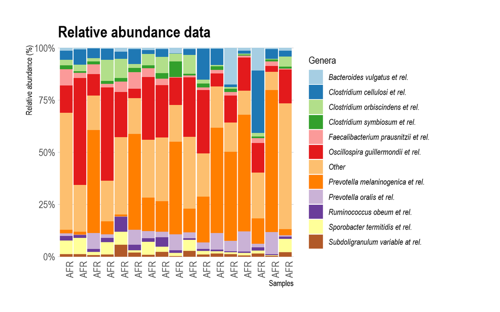

```r
# Limit the analysis on core taxa and specific sample group
p <- plot_composition(pseq2,
                      taxonomic.level = "Genus",
                      sample.sort = "nationality",
                      x.label = "nationality") +
  scale_fill_brewer("Genera", palette = "Paired") +
  guides(fill = guide_legend(ncol = 1)) +
  scale_y_percent() +
  labs(x = "Samples", y = "Relative abundance (%)",
       title = "Relative abundance data") +
  theme_ipsum(grid="Y") +
  theme(axis.text.x = element_text(angle=90, hjust=1),
        legend.text = element_text(face = "italic"))
print(p)
```

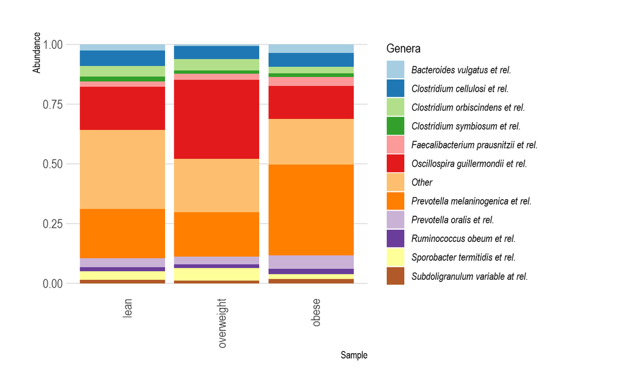

```r
# Averaged by group
p <- plot_composition(pseq2,
                      average_by = "bmi_group",
                      transform = "compositional") +
  scale_fill_brewer("Genera", palette = "Paired") +
  theme_ipsum(grid="Y") +
  theme(axis.text.x = element_text(angle=90, hjust=1),
        legend.text = element_text(face = "italic"))
print(p)
```

```r
p <- NULL
```

## Composition heatmaps

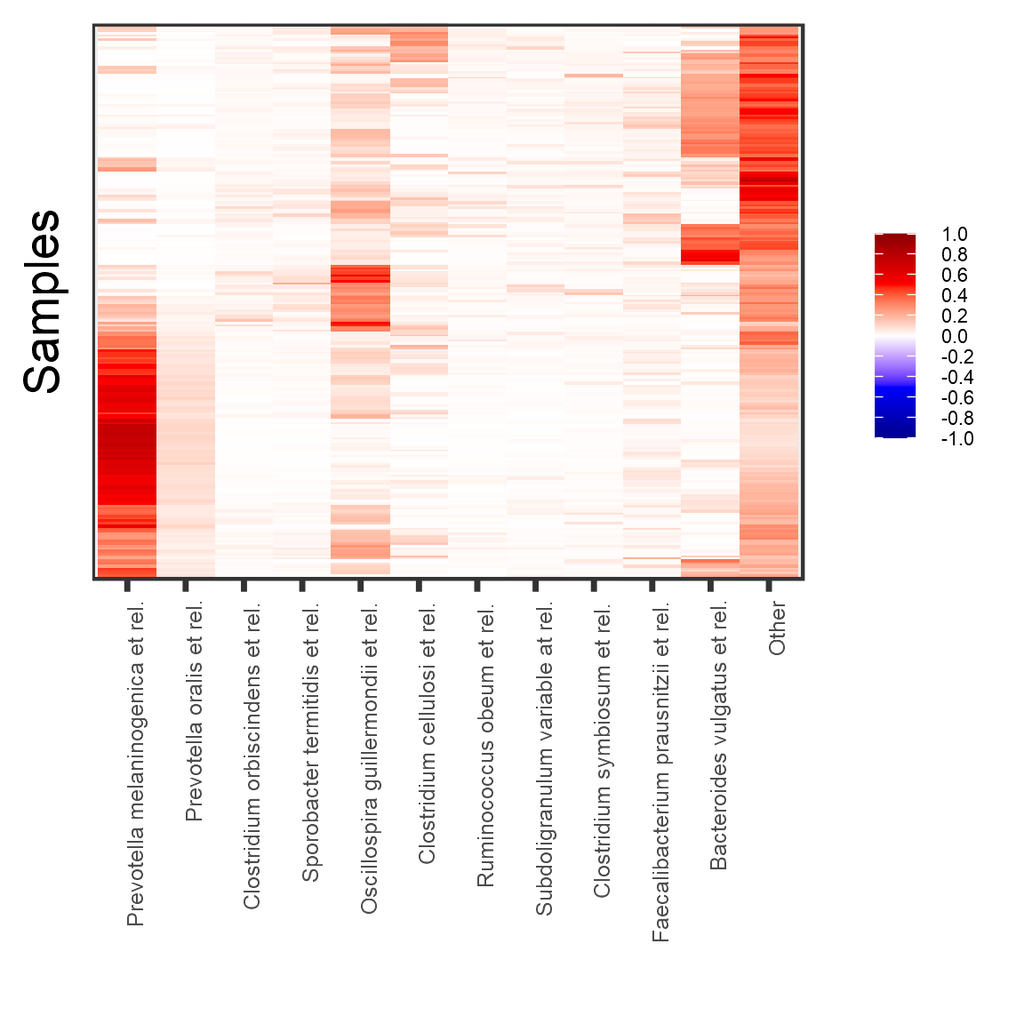

```r
p <- microbiome::transform(pseq, "compositional") %>%
  plot_composition(plot.type = "heatmap",
                   sample.sort = "neatmap",
                   otu.sort = "neatmap") +
  theme(axis.text.y=element_blank(),
        axis.ticks.y = element_blank(),
        axis.text.x = element_text(size = 9, hjust=1),
        legend.text = element_text(size = 8)) +
  ylab("Samples")
print(p)
```

## Plot taxa prevalence

This function allows you to have an overview of OTU prevalences alongwith their taxonomic affiliations. This will aid in checking if you filter OTUs based on prevalence, then what taxonomic affliations will be lost.

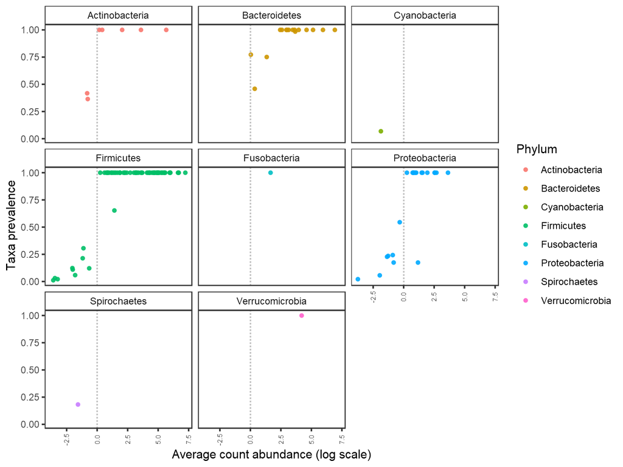

```r
data(atlas1006)

# Use sample and taxa subset to speed up example
p0 <- subset_samples(atlas1006, DNA_extraction_method == "r")

# Define detection and prevalence thresholds to filter out rare taxa
p0 <- core(p0, detection = 0.1/100, prevalence = 1/100)

# For the available taxonomic levels
plot_taxa_prevalence(p0, "Phylum", detection = 0.1/100)
```

## Amplicon data

Also see [phyloseq barplot examples](http://joey711.github.io/phyloseq/plot_bar-examples.html).

Here the data from [Thompson, Luke R., et al. “A communal catalogue reveals Earth’s multiscale microbial diversity.” Nature 551.7681 (2017): 457-463.](https://www.nature.com/articles/nature24621/) will be used which is stored as example in jeevanuDB

Check the [core microbiome page](http://microbiome.github.io/tutorials/CoremicrobiotaAmplicon.html) which shows how to read the your files into R and make a phyloseq object.

```r
# Example data
library(microbiome)
# Try another theme
# from https://github.com/hrbrmstr/hrbrthemes
# you can install these if you don't have it already.
# devtools::install_github("hrbrmstr/hrbrthemes")
library(hrbrthemes)
library(gcookbook)
library(tidyverse)
library(dplyr)
library(jeevanuDB)
```

```r
ps1 <- emp_human
colnames(tax_table(ps1))
```

```
## [1] "Domain"  "Phylum"  "Class"   "Order"   "Family"  "Genus"   "Species"
```

```r
tax_table(ps1)[tax_table(ps1)[,"Domain"]== "NA", "Domain" ] <- "Unidentified_Domain"
```

# Composition barplots

The composition plots can be shown either as barplots or heatmaps. Both examples are show below.

## Plot counts abundance

Now we can improve the plot further.  
Let’s try at Family level.

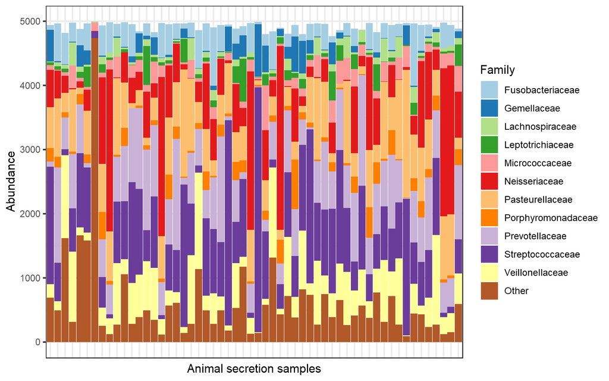

```r
library(phyloseq)
# merge at family level.
# check how many samples are there
# Use only saliva samples
ps1.saliva <- subset_samples(ps1, env_material == "saliva")
total_samples <- phyloseq::nsamples(ps1.saliva)

ps1.saliva.pruned <- prune_taxa(taxa_sums(ps1.saliva) >0, ps1.saliva)

# merge all taxa that are detected rare
pseq.fam <- aggregate_rare(ps1.saliva.pruned, level="Family", detection = 50, prevalence = 25/total_samples)

# Remove the "f__" before the family names
taxa_names(pseq.fam) <- gsub("f__", "", taxa_names(pseq.fam) )

p.fam <- plot_composition(pseq.fam, sample.sort = NULL,
                          otu.sort = NULL,
                          plot.type = "barplot",
                          verbose = FALSE) +
  xlab("Animal secretion samples") +
  theme_bw() +
  theme(axis.text.x = element_blank(),
        axis.ticks.x=element_blank()) +
  scale_fill_brewer("Family", palette = "Paired")

p.fam
```

## Plot relative abundance

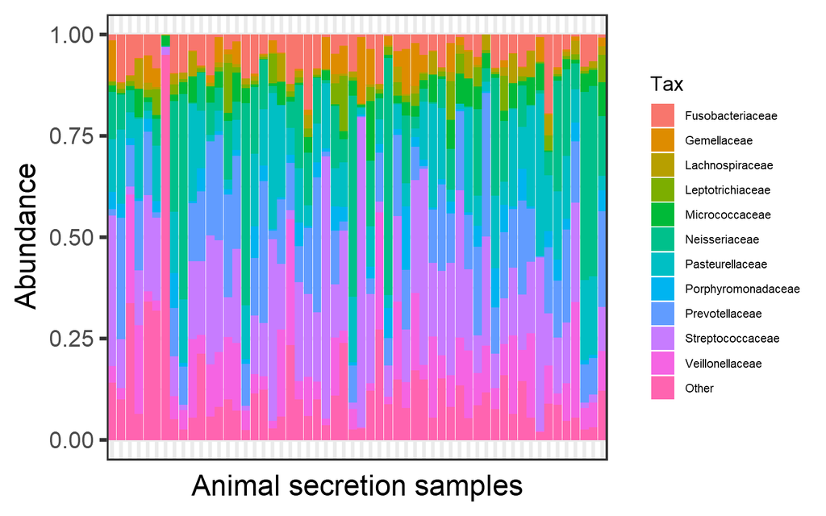

```r
pseq.famrel <- microbiome::transform(pseq.fam, "compositional")

p.famrel <- plot_composition(pseq.famrel,
                             sample.sort = NULL,
                             otu.sort = NULL,
                             x.label = "empo_3",
                             plot.type = "barplot",
                             verbose = FALSE) +
  # Removes sample names and ticks, and adjusts the size of legend texts
  theme(axis.text.x=element_blank(),
        axis.ticks.x=element_blank(),
        legend.text=element_text(size=8),
        legend.title =element_text(size=14)) +
  xlab("Animal secretion samples")

print(p.famrel)
```

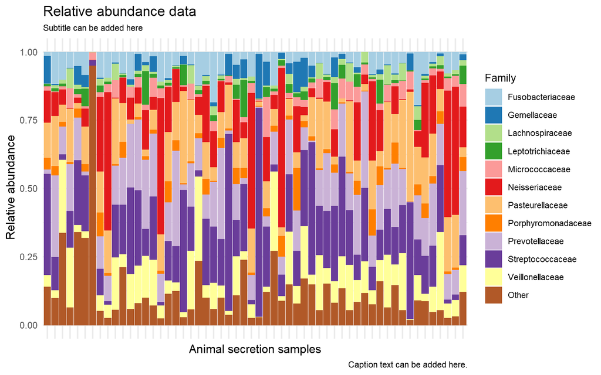

```r
# further improvements can be done as follows
p.famrel <- plot_composition(pseq.famrel,
                             sample.sort = NULL,
                             otu.sort = NULL,
                             x.label = "empo_3",
                             plot.type = "barplot",
                             verbose = FALSE) +
  theme_minimal() +
  guides(fill = guide_legend(ncol = 1)) +
  labs(x = "Animal secretion samples",
       y = "Relative abundance",
       title = "Relative abundance data",
       subtitle = "Subtitle can be added here",
       caption = "Caption text can be added here.") +
  scale_fill_brewer("Family", palette = "Paired") +

  #Removes sample names and ticks
  theme(axis.text.x=element_blank(),
        axis.ticks.x=element_blank()) +
  #Adjusts size of subtitle, caption, legend text and legend title
  theme(plot.subtitle=element_text(size=8),
        plot.caption=element_text(size=8),
        legend.text=element_text(size=8),
        legend.title =element_text(size=10))

print(p.famrel)
```

Average by group

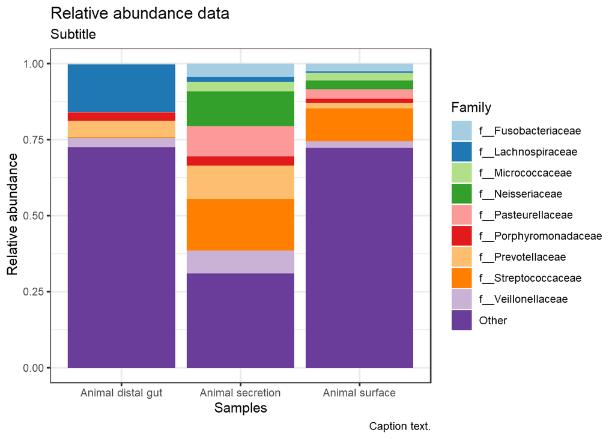

```r
# Averaged by group

# Use all samples
ps1 <- emp_human
# get relative abudance
ps1.rel <- microbiome::transform(ps1, "compositional")
ps1.fam.rel <-aggregate_rare(ps1.rel, level = "Family", detection = 0.005, prevalence = 0.5)

p <- plot_composition(ps1.fam.rel,
                      average_by = "empo_3") +
  guides(fill = guide_legend(ncol = 1)) +
  labs(x = "Samples",
       y = "Relative abundance",
       title = "Relative abundance data",
       subtitle = "Subtitle",
       caption = "Caption text.")
print(p + scale_fill_brewer("Family", palette = "Paired") + theme_bw())
```

# Heatmap composition

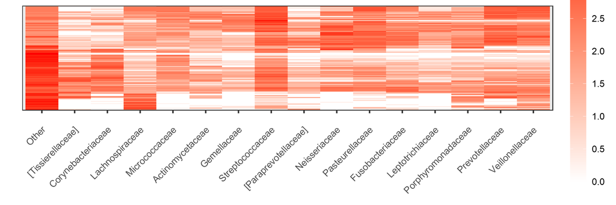

```r
# Use all samples
ps1 <- emp_human

ps1.rel <-aggregate_rare(ps1, level = "Family", detection = 10, prevalence = 0.5)

pseq.famlog <- microbiome::transform(ps1.rel, "log10")
# Remove the "f__" before the family names
taxa_names(pseq.famlog) <- gsub("f__", "", taxa_names(pseq.famlog) )
p.famrel.heatmap <- plot_composition(pseq.famlog,
                                     sample.sort = NULL,
                                     otu.sort = NULL,
                                     x.label = "empo_3",
                                     plot.type = "heatmap",
                                     verbose = FALSE) +

  #Adjusts the legend. Lowest values are white and highest red.
  #Breaks are distributed evenly from lowest values to highest with increment of 0.5.
  scale_fill_gradient(low = "white", high = "red", breaks = seq(min(pseq.famlog@otu_table),max(pseq.famlog@otu_table),0.5)) +

  #Deletes y-axis labels and ticks. Adjusts legend key size and deletes legend title. Adjusts x axis labels.
  theme(axis.text.y = element_blank(),
        axis.ticks.y = element_blank(),
        legend.key.height = unit(3, "cm"),
        legend.key.width = unit(1, "cm"),
        legend.title = element_blank(),
        axis.text.x = element_text(angle = 45,
                                   vjust = 0.85,
                                   hjust = 1))


print(p.famrel.heatmap)
```

## Plot core taxa time trajectory

```r
library(dplyr)
# select core
ps <- moving_pictures
table(meta(ps)$sample_type, meta(ps)$host_subject_id)
```

```
##
##           F4  M3
##   saliva 135 373
##   skin   268 723
##   stool  131 336
```

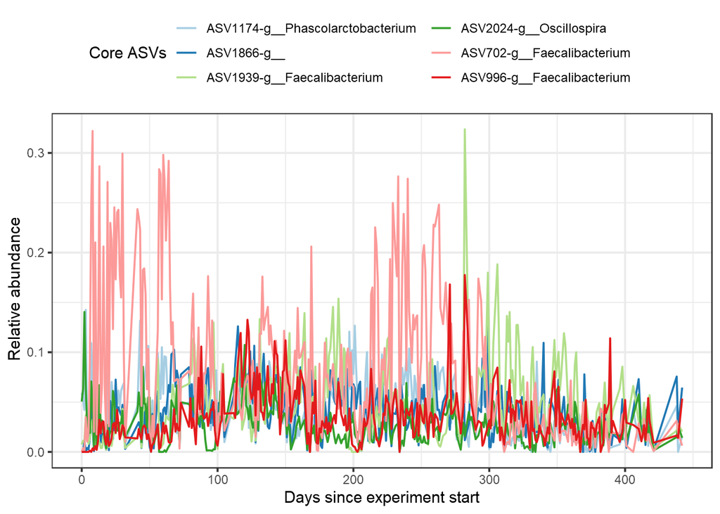

```r
taxa_names(ps) <- paste0("ASV", seq(ntaxa(ps)))
# Filter the data to include only gut samples from M3 subject
ps.m3 <- subset_samples(ps, sample_type == "stool" & host_subject_id == "M3")
#print(ps.m3)

ps.m3.rel <- microbiome::transform(ps.m3, "compositional")
pseq.core <- core(ps.m3.rel, detection = 0.001, prevalence = .95)

ps.stool.df <- psmelt(pseq.core)
#head(ps.stool.df)

# add genus name to ASVid
ps.stool.df <- ps.stool.df %>%
  mutate(asv_gen= paste0(OTU, "-",Genus))

ps.stool.rel.plot <- ggplot(ps.stool.df) +
  geom_line(aes(days_since_experiment_start,
                Abundance, color = asv_gen)) +
  theme_bw() +
  theme(legend.position="top") +
  xlab("Days since experiment start") +
  ylab("Relative abundance") +
  scale_color_brewer("Core ASVs",palette = "Paired") +
  guides(col = guide_legend(ncol = 3, nrow = 3))

ps.stool.rel.plot
```

Highlight only one ASVs of interest.

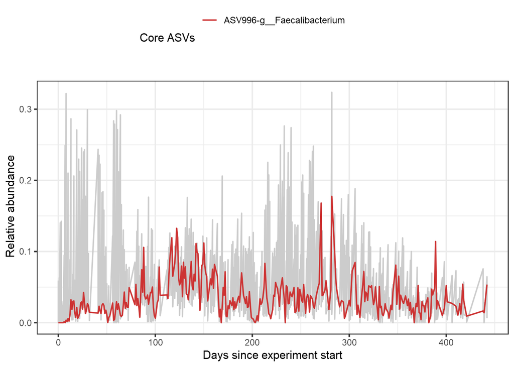

```r
ps.highlight.plot <- ggplot(ps.stool.df) +
  geom_line(aes(days_since_experiment_start,
                Abundance), color="grey80")
# pick only data for ASV996-g__Faecalibacterium

asv996 <- subset(ps.stool.df, asv_gen =="ASV996-g__Faecalibacterium")

ps.highlight.plot <- ps.highlight.plot +
  geom_line(data= asv996,aes(x=days_since_experiment_start,
                             y=Abundance, color=asv_gen)) +
  theme_bw() +
  theme(legend.position="top") +
  xlab("Days since experiment start") +
  ylab("Relative abundance") +
  scale_color_manual("Core ASVs",values="brown3") +
  guides(col = guide_legend(ncol = 3, nrow = 3))

ps.highlight.plot
```

More options for highlighting specific aspects of ggplot can be done with [gghighlight](https://cran.r-project.org/web/packages/gghighlight/vignettes/gghighlight.html).